# Boot a Bird

ESCI 599: Machine Learning

Andy Bunn

Built with `R` version 4.0.2 and `RStudio` version 1.3.1056. You should be either up to date or at least close to up to date on your versions of `R`, `RStudio`, and all the packages.

## Big Idea

Bootstrapping is a resampling technique that allows for an empirical estimation of the sampling distribution of almost any statistic independent of mathematical theory. We typically use it to get a range for a statistic (e.g., mean, median, etc). With bootstrapping we can understand the variance of almost any sample estimate as well as things like bias and confidence intervals. Bootstrapping can be used, therefore, as alternative to the traditional method of hypothesis testing.

## Reading

[This reading by Trist’n Joseph](https://towardsdatascience.com/bootstrapping-statistics-what-it-is-and-why-its-used-e2fa29577307) is quite good and a gentle introduction to bootstrapping. The idea that bootstrapping can be used as alternative to the traditional method of hypothesis testing as described in [this reading by Jim Frost](https://statisticsbyjim.com/hypothesis-testing/bootstrapping/)

Joseph T. 2017. Bootstrapping Statistics. What it is and why it’s used. Towards data science. https://towardsdatascience.com/bootstrapping-statistics-what-it-is-and-why-its-used-e2fa29577307. Accessed: 29-December-2020 12:23.

Frost, J. “Introduction to Bootstrapping in Statistics with an Example”. Statistics by Jim. https://statisticsbyjim.com/hypothesis-testing/bootstrapping/. Accessed: 29-December-2020 12:23.

## Packages

```r
library(tidyverse)
library(boot)
```

## Bird Diversity Data

We are going to look at some cool bird diversity data. The file `KillarneyBirds.csv` contains data on 31 species of birds across nine different habitats in County Killarney Ireland. The values are the number of territories held by breeding males in equal-sized blocks of woodland habitat. Here is the source:

Batten L. A. (1976) Bird communities of some Killarney woodlands. Proceedings of the Royal Irish Academy 76:285-313.

And the data.

```r
birds <- read_csv("KillarneyBirds.csv")
birds
```

```
## # A tibble: 31 x 10
##    Species            Oak1  Oak2  Oak3   Yew Sitka Norway Mixed Patchy Swampy
##    <chr>             <dbl> <dbl> <dbl> <dbl> <dbl>  <dbl> <dbl>  <dbl>  <dbl>
##  1 Chaffinch            35    41    31     9    14     30    10     13     15
##  2 Robin                26    35    23    20    10     30    18     12     20
##  3 BlueTit              25    19    17    10     0      3     7      8      5
##  4 Goldcrest            21    27    17    21    30     65    15     22     11
##  5 Wren                 16     8     1     5     4     20    10     14     10
##  6 CoalTit              11     9     8    14     6     11     4      6      5
##  7 SpottedFlycatcher     6     4     0     0     0      0     1      3      0
##  8 TreeCreeper           5     8     4     3     0      4     2      3      2
##  9 Blackbird             3     3     1     6     3     14     7      8      8
## 10 Siskin                3     2     2     2     7      2     3      5      4
## # … with 21 more rows
```

A quick heatmap.

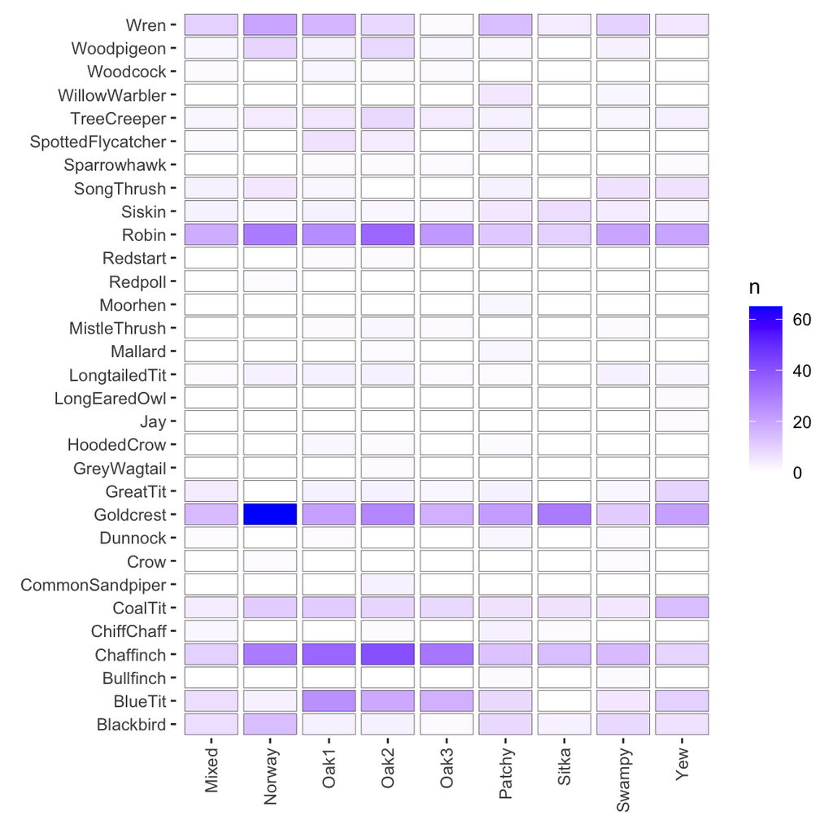

```r
birdsLong <- birds %>% pivot_longer(cols=-1,names_to="Habitat",values_to="n")
ggplot(data=birdsLong,mapping = aes(y=Species,x=Habitat,fill=n)) +
  geom_tile(color="black", width=0.9, height=0.9) +
  scale_fill_gradient(low="white", high="blue") +
  labs(x=element_blank(),y=element_blank()) +
  theme(axis.text.x = element_text(angle = 90, vjust = 0.5, hjust=1),
        panel.background = element_blank())
```

You can see on here that different species are associated with different habitats. Our question is, I guess, do the habitats differ in terms of diversity?

## Diversity

One of the most common and basic descriptions used in community ecology is diversity. Here we will look at using Simpson’s Diversity Index (SDI) to describe the variation in bird species community by habitat. This is one of the most common statistics using in community ecology and takes into account both the total number of species present as well as their relative abundance. It ranges from zero to one with higher numbers indicating higher diversity. Simpson’s $D$ is calculated as:

$$D = 1 - \frac{\sum_{i=1} n_i(n_i-1)}{N(N-1)}$$
where $n$ is the number of individuals of each species ($i$) and $N$ is the total number of individuals of all species. So let’s look at the count of birds in habitat `oak1` as `n`

```r
n <- birds$Oak1
n
```

```
##  [1] 35 26 25 21 16 11  6  5  3  3  3  3  3  2  2  2  1  1  1  1  0  0  0  0  0
## [26]  0  0  0  0  0  0
```

And the total of `n` as `N`.

```r
N <- sum(n)
N
```

```
## [1] 170
```

From that we can calculate $D$.

$$1 - \frac{35(34)+26(25)+25(24)+21(20)+16(15)+11(10)+...}{170(169)}$$
Here is $D$ implemented.

```r
D <- 1 - sum(n*(n-1)) / (N*(N-1))
D
```

```
## [1] 0.8853
```

We can write a function to do this for any vector of species. I’ll walk through how to write functions a bit in the video. It’s a very useful skill.

```r
sdiFunc <- function(x){
  N <- sum(x)
  D <- 1 - sum(x*(x-1)) / (N*(N-1))
  D
}
oak1Div <- sdiFunc(x=birds$Oak1)
oak1Div
```

```
## [1] 0.8853
```

And if we want to, we can `apply` that function to all the columns (habitats) in `birds`.

```r
sdiHabitat <- apply(birds[,-1], MARGIN = 2, FUN=sdiFunc)
sdiHabitat
```

```
##   Oak1   Oak2   Oak3    Yew  Sitka Norway  Mixed Patchy Swampy
## 0.8853 0.8739 0.8348 0.8911 0.7780 0.8285 0.8996 0.9180 0.9044
```

Note that I dropped the first column of species names before applying the function and specified that I wanted to calculate over the columns with `MARGIN=2`.

Here is a quick visualization of bird diversity by habitat.

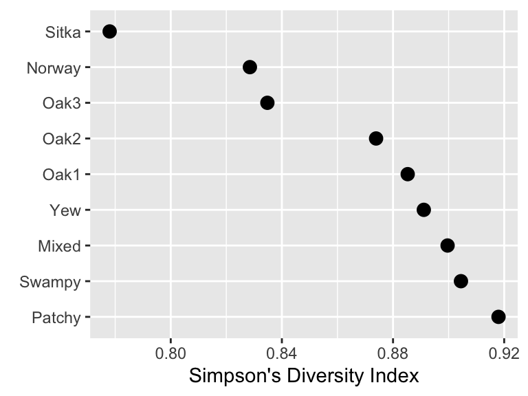

```r
sdiHabitat <- sdiHabitat %>% as_tibble %>% add_column(Habitat = names(sdiHabitat))
ggplot(data = sdiHabitat, mapping = aes(x=value,y=reorder(Habitat,-value))) +
  geom_point(size=3) +
  labs(x="Simpson's Diversity Index",y=element_blank())
```

Looking at this we see that the `Sitka` and `Norway` habitat are lowest in diversity – poor spruce and pine. The `Mixed`, `Swampy`, and `Patchy` habitats are the highest. But we don’t know from looking at this if the differences are substantial. We’d like to have a measure of variance of the diversity for each of these habitats and then infer if these differences are “meaningful” (for your definition of “meaningful”) or even “significant” (shudder).

## Roll your own bootstrap for one habitat

We can get an idea of the shape of the distribution of diversirt for each habitat with the bootstrap. Here we go with 10,000 bootstrap replicates (`R`) of the diversity for `oak1`. Note the `replace=TRUE` in `sample`. That is the key for this method. Refer back to the video for why and how that works.

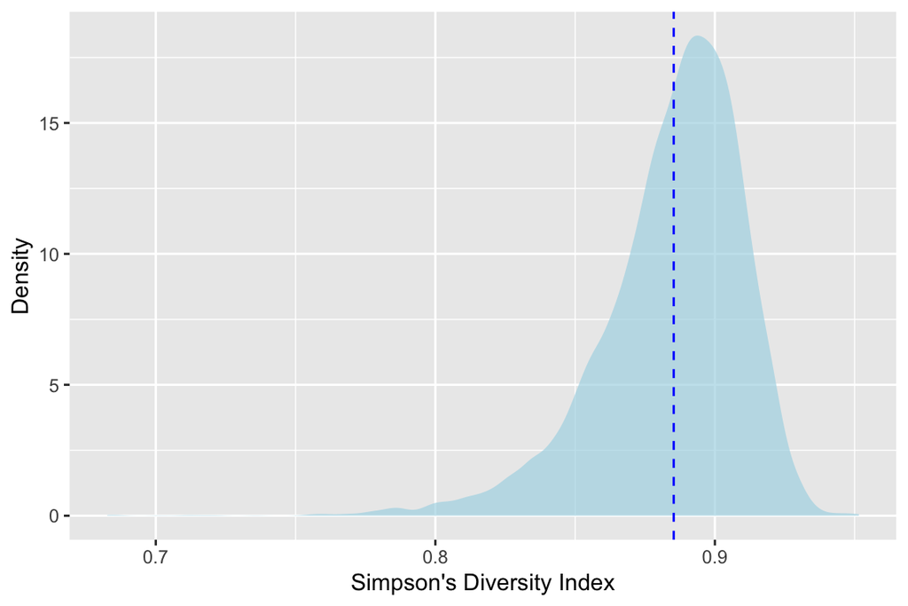

```r
R <- 1e4
# structure to hold results
sdiDistOak1 <- numeric()
for(i in 1:R){
  x <- birds$Oak1
  xSamp <- sample(x,size=length(x),replace=TRUE)
  sdiDistOak1[i] <- sdiFunc(xSamp)
}

ggplot() + geom_density(mapping=aes(x=sdiDistOak1),
                        fill="lightblue",color=NA,alpha=0.7) +
  geom_vline(xintercept = oak1Div,color="blue",linetype="dashed") +
  labs(x="Simpson's Diversity Index",y="Density")
```

(Go ahead and rerun that with smaller values of `R` – say 100 or 1000 – and see how the shape of the density plots changes.)

Ok. This is cool We see the calculated value of $D_{oak1}$ with the dotted line at 0.885. But with the shaded density plot we can see the distribution. And further more we can see that it’s not normal. The mean of that distribution is where our line is, but we have so much more information now.

```r
mean(sdiDistOak1)
```

```
## [1] 0.8845
```

For instance we can use the `quantile` method to get a confidence interval around that mean. By taking the 2.5% and the 97.5% percentiles we can see where the mean would fall in 95% of the bootstrap estimates ($\alpha/2$). Let’s get that and plot it.

```r
ci95Oak1 <- quantile(sdiDistOak1,probs = c(0.025,0.975))
names(ci95Oak1) <- c("lower","upper")
ci95Oak1
```

```
##  lower  upper
## 0.8217 0.9224
```

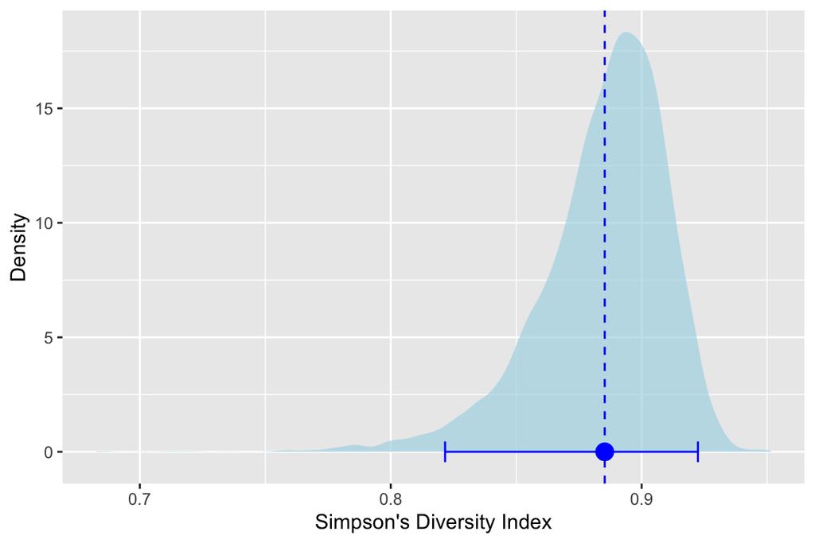

```r
ggplot() + geom_density(mapping=aes(x=sdiDistOak1),fill="lightblue",color=NA,alpha=0.7) +
    geom_vline(xintercept = oak1Div,color="blue",linetype="dashed") +
  geom_errorbarh(mapping=aes(xmin=ci95Oak1[1],xmax=ci95Oak1[2],y=0),
                              color="blue") +
  geom_point(mapping=aes(x = oak1Div,y=0),
             color="blue",size=4) +
    labs(x="Simpson's Diversity Index",y="Density")
```

We see the estimate and its variance and with this visualization we see how the skew of the bootstrapped estimates of $D_{oak1}$ lead to asymmetric lower and upper confidence intervals around the mean. Very cool.

You could now do this for all of the habitats and make some inference about whether the differences in diversity are “real” (or “meangingful” or “significant”).

### Do it with `boot`

While writing loops is cool and makes you feel like a real programmer, there are loads of ways to do this in R using prefabricated functions. I’m being a little flip here – I actually like writing my own functions and loops because I know exactly what’s going on. But one should do that only to a point.

The `boot` library in R is one of the most commonly used tools for resampling. I’ve been using R for 20 years (seriously) and I still find the syntax confusing for `boot`. The idea makes sense though. Any function that you write with a test statistic can be passed into `boot` which will do the looping for you with much greater efficiency than the loops you write yourself. I’ll try to explain why in the video.

So here is a function that replaces our `sdiFunc` in a way that `boot` understands. Basically it uses the `indices` argument to do the looping that we did with `sdiFunc` above.

```r
# this is a function boot will understand
sdiBootFunc <- function(x, indicies) {
  y <- x[indicies]
  N <- sum(y)
  D <- 1 - sum(y*(y-1)) / (N*(N-1))
  D
}
# the actual bootstrapping with R replicates
sdiOakBoot <- boot(birds$Oak1, sdiBootFunc, R=1e4)
sdiOakBoot
```

```
##
## ORDINARY NONPARAMETRIC BOOTSTRAP
##
##
## Call:
## boot(data = birds$Oak1, statistic = sdiBootFunc, R = 10000)
##
##
## Bootstrap Statistics :
##     original     bias    std. error
## t1*   0.8853 -4.104e-05     0.02549
```

Take a look at `sdiOakBoot`. It is a `list` with many objects but the key ones are `t0` wihch is the original test statistic $D$ and `t` which contains all the bootstrapped estimates of $D$. Note that there are 10,000 of them corresponding to `R`.

With that we can replicate our plot above.

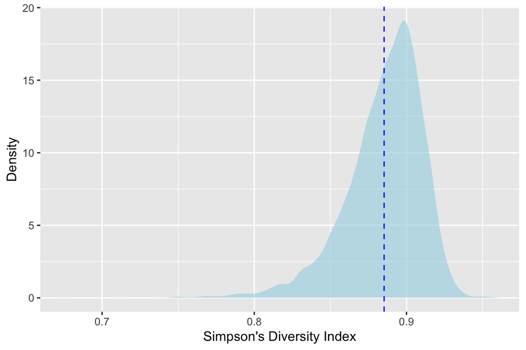

```r
ggplot() + geom_density(mapping=aes(x=sdiOakBoot$t),
                        fill="lightblue",color=NA,alpha=0.7) +
  geom_vline(xintercept = sdiOakBoot$t0,color="blue",linetype="dashed") +
  labs(x="Simpson's Diversity Index",y="Density")
```

And we can even use the `boot.ci` function to calculate several different flavors of confidence intervals.

```r
boot.ci(sdiOakBoot)
```

```
## BOOTSTRAP CONFIDENCE INTERVAL CALCULATIONS
## Based on 10000 bootstrap replicates
##
## CALL :
## boot.ci(boot.out = sdiOakBoot)
##
## Intervals :
## Level      Normal              Basic
## 95%   ( 0.8354,  0.9353 )   ( 0.8478,  0.9466 )
##
## Level     Percentile            BCa
## 95%   ( 0.8239,  0.9228 )   ( 0.8127,  0.9189 )
## Calculations and Intervals on Original Scale
```

I won’t spoil the fun by describing all of them (`Normal` vs `Basic` vs `Percentile` vs `BCa`). Do some reading and experiment. Holler with questions.

## Your work

Go ahead and calculate bootstraps of $D$ for for each habitat (Norway, Sitka, etc.) either with your own loop or with `boot`. Report on which habitats have differences in bird community diversity. You can calculate confidence intervals if you like or just do some visualizations. Report on what you see.